```python
import platform
import datetime
import sys
import os


your_name, your_code, work_counter = "杜培博", 200507340136, 10
print(f'我是：{your_name}，学号：{your_code}，这是我的第 {work_counter} 次作业。')
print('现在是', datetime.datetime.now())
print('我的机器信息如下：')
print(platform.uname())

print('\n当前工作目录：')
print(os.getcwd())
print('\n当前目录的文件信息如下：')
print(os.listdir())
print('\n我安装包的情况:')
!pip list
```

[output not shown]

[output cut: 82 more lines]

[output not shown]

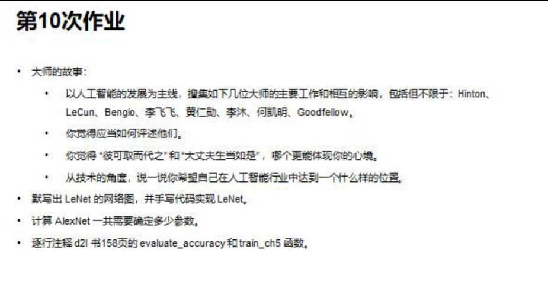

# 大师的故事

#### ·搜集大师的主要工作和影响：

Hinton：“深度学习领域的三大先驱之一”获得图灵奖，被彭博社选为2017年改变全球商业格局的50人，Hinton率先将反向传播(Backpropagation)用于多层神经网络，发明了玻尔兹曼机(Boltzmann machine)，提出逐层初始化预训练方法揭开了深度学习的序幕，提出了胶囊神经网络(capsule network)，发表了多篇论文，

LeCun：卷积神经网络之父，Facebook人工智能实验室主任，NYU数据科学中心创始人，计算机科学、神经科学、电子电气科学教授。

Yoshua Bengio：是世界级人工智能专家和深度学习“三巨头”之一，现任蒙特利尔学习算法研究所（Mila）创始人和科学主任，蒙特利尔大学教授，迄今发表过 300 多篇学术文章，引用超过 8 万次

李飞飞：李飞飞的工作包括括受认知启发的AI，机器学习，深度学习，计算机视觉和AI+医疗保健，尤其是用于医疗保健交付的环境智能系统。她还从事认知和计算神经科学方面的工作。她发明了ImageNet和ImageNet Challenge，其中ImageNet Challenge是一项重要的大规模数据集和基准测试工作

李沐：2008年毕业于上海交通大学计算机系,大学期间，曾在微软亚洲研究院担任实习生。2017年博士毕业后，李沐加入亚马逊任AI主任科学家

何恺明：荣登AI全球最具影响力学者榜单，2022年人工智能全球最具影响力学者榜单公布，何恺明获得第一名

Goodfellow：因提出了生成对抗网络（GANs）而闻名，他被誉为“GANs之父”，甚至被推举为人工智能领域的顶级专家

#### ·如何评价

引领了人工智能的发展潮流，他们推动着人工智能的发展，是使人工智能变得越来越智能，改变了人的生活

#### ·你觉得“彼可取而代之"和“大丈夫生当如是”，哪个更能体现你的心境。

大丈夫生当如是，我局的没必要去取代他，应更应该向他们学习，以他们为榜样，我们也会能成为一个伟大的人

#### ·从技术的角度，说一说你希望自己在人工智能行业中达到一个什么样的位詈。

学好英语，做一个算法工程师，研究前沿的学术，做技术，为人工智能发展作贡献

# ·默写出LeNet的网络图，手写代码实现LeNet

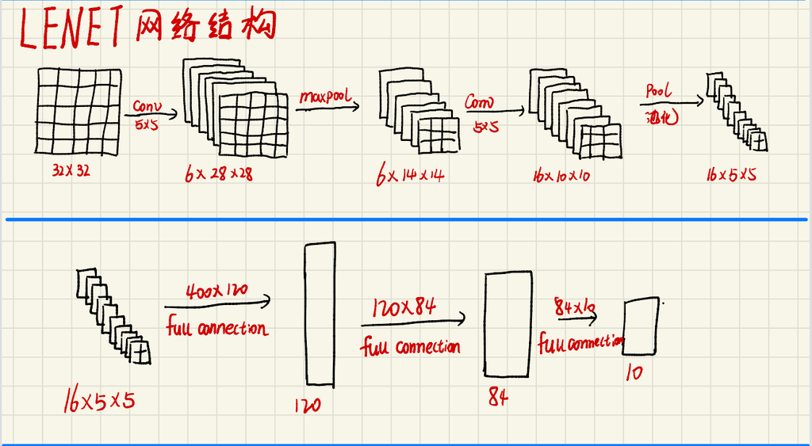

#### 手写代码实现LeNet

```python
import torch
from torch import nn, optim
import sys
sys.path.append("..")
import d2lzh_pytorch as d2l
device = torch.device('cuda' if torch.cuda.is_available() else'cpu')
```

### LeNet网络：搭积木

```python
class LeNet(nn.Module):
    def __init__(self):
        super(LeNet, self).__init__()
        self.conv1 = nn.Conv2d(1, 6, 5, 1)
        self.sig1 = nn.Sigmoid()
        self.pool1 = nn.MaxPool2d(2, 2)
        self.conv2 = nn.Conv2d(6, 16, 5, 1)
        self.sig2 = nn.Sigmoid()
        self.pool2 = nn.MaxPool2d(2, 2)
        self.fla1 = nn.Flatten()
        self.linear1 = nn.Linear(400, 120)
        self.sig3 = nn.Sigmoid()
        self.linear2 = nn.Linear(120, 84)
        self.sig4 = nn.Sigmoid()
        self.linear3 = nn.Linear(84, 10)

    def forward(self, x):
        x = self.conv1(x)
        x = self.sig1(x)
        x = self.pool1(x)
        x = self.conv2(x)
        x = self.sig2(x)
        x = self.pool2(x)
        x = self.fla1(x)
        x = self.linear1(x)
        x = self.sig3(x)
        x = self.linear2(x)
        x = self.sig4(x)
        y = self.linear3(x)
        return y


net = LeNet()
net
```

```
LeNet(
  (conv1): Conv2d(1, 6, kernel_size=(5, 5), stride=(1, 1))
  (sig1): Sigmoid()
  (pool1): MaxPool2d(kernel_size=2, stride=2, padding=0, dilation=1, ceil_mode=False)
  (conv2): Conv2d(6, 16, kernel_size=(5, 5), stride=(1, 1))
  (sig2): Sigmoid()
  (pool2): MaxPool2d(kernel_size=2, stride=2, padding=0, dilation=1, ceil_mode=False)
  (fla1): Flatten(start_dim=1, end_dim=-1)
  (linear1): Linear(in_features=400, out_features=120, bias=True)
  (sig3): Sigmoid()
  (linear2): Linear(in_features=120, out_features=84, bias=True)
  (sig4): Sigmoid()
  (linear3): Linear(in_features=84, out_features=10, bias=True)
)
```

```python
net = nn.Sequential()
net.add_module("conv1", nn.Conv2d(in_channels=1, out_channels=6, kernel_size=5))
net.add_module("sig1", nn.Sigmoid())
net.add_module("pool1", nn.MaxPool2d(kernel_size=2, stride=2))
net.add_module("conv2", nn.Conv2d(in_channels=6, out_channels=16, kernel_size=5))
net.add_module("sig2", nn.Sigmoid())
net.add_module("pool2", nn.MaxPool2d(kernel_size=2, stride=2))
net.add_module("flatten", nn.Flatten())
net.add_module("linear1", nn.Linear(400, 120))
net.add_module("sig3", nn.Sigmoid())
net.add_module("linear2", nn.Linear(120, 84))
net.add_module("sig4", nn.Sigmoid())
net.add_module("linear3", nn.Linear(84, 10))

net
```

```
Sequential(
  (conv1): Conv2d(1, 6, kernel_size=(5, 5), stride=(1, 1))
  (sig1): Sigmoid()
  (pool1): MaxPool2d(kernel_size=2, stride=2, padding=0, dilation=1, ceil_mode=False)
  (conv2): Conv2d(6, 16, kernel_size=(5, 5), stride=(1, 1))
  (sig2): Sigmoid()
  (pool2): MaxPool2d(kernel_size=2, stride=2, padding=0, dilation=1, ceil_mode=False)
  (flatten): Flatten(start_dim=1, end_dim=-1)
  (linear1): Linear(in_features=400, out_features=120, bias=True)
  (sig3): Sigmoid()
  (linear2): Linear(in_features=120, out_features=84, bias=True)
  (sig4): Sigmoid()
  (linear3): Linear(in_features=84, out_features=10, bias=True)
)
```

```python
class LeNet(nn.Module):
    def __init__(self):
        super(LeNet, self).__init__()
        self.conv = nn.Sequential(
            nn.Conv2d(1, 6, 5), # in_channels, out_channels, kernel_size
            nn.Sigmoid(),
            nn.MaxPool2d(2, 2), # kernel_size, stride
            nn.Conv2d(6, 16, 5),
            nn.Sigmoid(),
            nn.MaxPool2d(2, 2)
        )
        self.fc = nn.Sequential(
            nn.Linear(16*4*4, 120),
            nn.Sigmoid(),
            nn.Linear(120, 84),
            nn.Sigmoid(),
            nn.Linear(84, 10)
        )

    def forward(self, img):
        feature = self.conv(img)
        output = self.fc(feature.view(img.shape[0], -1))
        return output
net = LeNet()
print(net)
```

```
LeNet(
  (conv): Sequential(
    (0): Conv2d(1, 6, kernel_size=(5, 5), stride=(1, 1))
    (1): Sigmoid()
    (2): MaxPool2d(kernel_size=2, stride=2, padding=0, dilation=1, ceil_mode=False)
    (3): Conv2d(6, 16, kernel_size=(5, 5), stride=(1, 1))
    (4): Sigmoid()
    (5): MaxPool2d(kernel_size=2, stride=2, padding=0, dilation=1, ceil_mode=False)
  )
  (fc): Sequential(
    (0): Linear(in_features=256, out_features=120, bias=True)
    (1): Sigmoid()
    (2): Linear(in_features=120, out_features=84, bias=True)
    (3): Sigmoid()
    (4): Linear(in_features=84, out_features=10, bias=True)
  )
)
```